# Causal Models

Selecting predictors with confidence

Philip Leftwich

University of East Anglia

2026-03-05

# Model Selection and Causal Inference

## Learning Objectives

By the end of this lecture, you should be able to:

1. Explain why automated variable selection is problematic
2. Understand when to use hierarchical regression
3. Identify confounders, colliders, and mediators
4. Use DAGs to make principled modelling decisions
5. Avoid common statistical pitfalls in model specification

## The Problem

You’ve measured 10 variables in your experiment. Which ones should go in your model?

**Common (wrong) answer**: “Let the computer decide!”

**Why this matters**:

- Poor selection → biased estimates
- Wrong variables → wrong conclusions
- Overfitting → results don’t replicate
- Inflated Type I error rates

> Your model specification is a scientific decision, not a statistical one

# Part 1: What NOT to Do

## Automated Variable Selection

**Common approaches you’ll encounter**:

**Stepwise methods**:

- Stepwise (AIC/p-values)

**Information criteria**: - AIC comparison

- Model dredging

**Problems**: - Capitalise on chance

- Inflated Type I error
- Unstable across samples
- Ignore causal structure
- Over-confident estimates

Harrell (2015); Heinze et al. (2018) “Step away from stepwise”

## AIC: What It Can and Can’t Do

**Akaike Information Criterion (AIC)**:

$$\text{AIC} = 2k - 2\ln(\hat{L})$$

- $k$ = number of parameters
- $\hat{L}$ = maximised likelihood
- Lower AIC = better balance of fit vs complexity
- Δ AIC < 2 suggests equivalent models

**AIC can**: - Compare non-nested models - Compare different GLM families

**AIC cannot**: - Compare models with transformed responses - Compare models with different datasets - Tell you which variables are *causally* important

## Model Dredging Example

```r
library(MuMIn)

# Fit model with all interactions
model <- lm(bill_length ~ bill_depth * body_mass * species,
            data = penguins,
            na.action = "na.fail")

# Try every possible combination
dredge(model)
```

```
   Model selection table
   df   AICc  delta  weight
24  8  1541.3  0.00   0.619
32  9  1543.2  1.94   0.234
56 10  1544.2  2.87   0.147
```

**Problems**: - Which model do you report? Top one? All of them?

- Model weights apply to entire models, not individual predictors
- Multicollinearity makes weights unreliable
- You’ve just run hundreds of tests without correction

## When IS Automated Selection Acceptable?

**Likelihood Ratio Tests** can be useful:

```r
# Test if interaction improves fit
model_full <- lm(height ~ fertiliser * sunlight, data = plants)

model_reduced <- lm(height ~ fertiliser + sunlight, data = plants)

anova(model_reduced, model_full)
```

**When this works**: - Testing a specific, pre-planned hypothesis - Comparing exactly two nested models - Not running **multiple** tests

**When it fails**: - Repeatedly testing many terms - “Fishing” for significance - No correction for multiple comparisons

# Part 2: A Better Approach - Hierarchical Regression

## Hierarchical Regression

**The idea**: Enter variables in theoretically motivated blocks

**Example**: Predicting blood pressure

**Block 1 - Demographics** (fundamental factors):

```r
model1 <- lm(blood_pressure ~ age + sex + ethnicity, data = health)
```

**Block 2 - Add Lifestyle** (potentially modifiable):

```r
model2 <- lm(blood_pressure ~ age + sex + ethnicity +
                              activity + smoking + alcohol + sleep,
             data = health)

anova(model1, model2)  # Does lifestyle add explanatory power?
```

## Why Hierarchical Regression Works

**Advantages**: - Transparent and defensible - Based on theory, not data mining - Dramatically reduces number of tests - Each test answers a meaningful question - Can work forwards or backwards

**Example questions**: - “Do lifestyle factors matter beyond demographics?” - “Does treatment work beyond baseline characteristics?” - “Do environmental variables add to genetic predictors?”

**Key principle**: You’re testing theoretical blocks, not individual variables

# Part 3: Causal Inference Basics

## Why Causality Matters

**Question**: Does smoking reduce lung capacity?

**You measure**:

- Age (10 - 35)
- Smoking (yes/no)
- Lung capacity

**You perform**: A simple regression (lung capacity ~ smoking)

**You find**: Smokers have a *greater lung capacity* (p < 0.001)

**But**: Only adults in the study are smokers

> So have you measured smokings effect on lung capacity or the effect of being an adult?

**Regression only estimates causal effects when the model reflects causal structure**

## Three Key Variable Types

**1. Confounder** → affects both exposure AND outcome

```
         Age
        ↙   ↘
   Exercise → Heart Disease
```

**2. Mediator** → on the causal pathway

```
Exercise → Weight Loss → Heart Disease
```

**3. Collider** → caused by two variables

```
Feeding → Predator Visits ← Egg Count
```

## Confounder

**1. Confounder** → affects both exposure AND outcome

```
         Age
        ↙   ↘
   Exercise → Heart Disease
```

Age makes you less likely to exercise AND increases heart disease risk

**Must adjust** to remove spurious association

## Confounder

```
Call:
lm(formula = heart_disease_risk ~ exercise, data = confounder_data)

Residuals:
     Min       1Q   Median       3Q      Max
-14.5994  -3.2692   0.0197   3.3976  14.4987

Coefficients:
            Estimate Std. Error t value Pr(>|t|)
(Intercept) 15.34572    0.84897   18.08   <2e-16 ***
exercise    -0.77495    0.03271  -23.69   <2e-16 ***
---
Signif. codes:  0 '***' 0.001 '**' 0.01 '*' 0.05 '.' 0.1 ' ' 1

Residual standard error: 5.204 on 498 degrees of freedom
Multiple R-squared:  0.5298,    Adjusted R-squared:  0.5289
F-statistic: 561.2 on 1 and 498 DF,  p-value: < 2.2e-16
```

```
Call:
lm(formula = heart_disease_risk ~ exercise + age, data = confounder_data)

Residuals:
    Min      1Q  Median      3Q     Max
-8.6504 -1.8530  0.0052  1.9055  8.0742

Coefficients:
            Estimate Std. Error t value Pr(>|t|)
(Intercept) -0.72146    0.67719  -1.065    0.287
exercise    -0.19940    0.02517  -7.921 1.55e-14 ***
age          0.61231    0.01844  33.203  < 2e-16 ***
---
Signif. codes:  0 '***' 0.001 '**' 0.01 '*' 0.05 '.' 0.1 ' ' 1

Residual standard error: 2.904 on 497 degrees of freedom
Multiple R-squared:  0.8539,    Adjusted R-squared:  0.8533
F-statistic:  1452 on 2 and 497 DF,  p-value: < 2.2e-16
```

## Mediator

**2. Mediator** → on the causal pathway

```
Exercise → Weight Loss → Heart Disease
```

Weight loss is HOW exercise works

**Don’t adjust** if you want *total effect*

**Do adjust** if you want *direct effect* only

## Mediator

```
Call:
lm(formula = heart_disease_risk ~ exercise, data = mediator_data)

Residuals:
    Min      1Q  Median      3Q     Max
-7.3846 -1.6723  0.0646  1.7385  8.4484

Coefficients:
            Estimate Std. Error t value Pr(>|t|)
(Intercept) -0.35860    0.38282  -0.937    0.349
exercise    -0.65826    0.07412  -8.881   <2e-16 ***
---
Signif. codes:  0 '***' 0.001 '**' 0.01 '*' 0.05 '.' 0.1 ' ' 1

Residual standard error: 2.415 on 498 degrees of freedom
Multiple R-squared:  0.1367,    Adjusted R-squared:  0.135
F-statistic: 78.87 on 1 and 498 DF,  p-value: < 2.2e-16
```

```
Call:
lm(formula = heart_disease_risk ~ exercise + weight_loss, data = mediator_data)

Residuals:
    Min      1Q  Median      3Q     Max
-5.7670 -1.2353  0.0035  1.2703  5.3828

Coefficients:
            Estimate Std. Error t value Pr(>|t|)
(Intercept) -0.34748    0.30696  -1.132 0.258175
exercise    -0.24720    0.06435  -3.841 0.000138 ***
weight_loss -0.69901    0.04196 -16.661  < 2e-16 ***
---
Signif. codes:  0 '***' 0.001 '**' 0.01 '*' 0.05 '.' 0.1 ' ' 1

Residual standard error: 1.936 on 497 degrees of freedom
Multiple R-squared:  0.4461,    Adjusted R-squared:  0.4439
F-statistic: 200.1 on 2 and 497 DF,  p-value: < 2.2e-16
```

## Collider

**3. Collider** → caused by two variables

```
Feeding → Predator Visits ← Egg Count
```

Both active birds AND large nests attract predators

**Never adjust** - creates spurious associations (collider bias)

## Collider

```
Call:
lm(formula = feeding_activity ~ egg_count, data = collider_data)

Residuals:
     Min       1Q   Median       3Q      Max
-29.5565  -6.3581  -0.0633   6.6760  30.0638

Coefficients:
            Estimate Std. Error t value Pr(>|t|)
(Intercept) 50.01491    1.73337  28.854   <2e-16 ***
egg_count   -0.03964    0.21087  -0.188    0.851
---
Signif. codes:  0 '***' 0.001 '**' 0.01 '*' 0.05 '.' 0.1 ' ' 1

Residual standard error: 9.731 on 498 degrees of freedom
Multiple R-squared:  7.094e-05, Adjusted R-squared:  -0.001937
F-statistic: 0.03533 on 1 and 498 DF,  p-value: 0.851
```

```
Call:
lm(formula = feeding_activity ~ egg_count + predator_visits,
    data = collider_data)

Residuals:
     Min       1Q   Median       3Q      Max
-20.0884  -5.0989  -0.2126   4.8628  23.1737

Coefficients:
                Estimate Std. Error t value Pr(>|t|)
(Intercept)     30.38365    1.68556  18.026  < 2e-16 ***
egg_count       -0.62092    0.16413  -3.783 0.000174 ***
predator_visits  0.99222    0.05265  18.845  < 2e-16 ***
---
Signif. codes:  0 '***' 0.001 '**' 0.01 '*' 0.05 '.' 0.1 ' ' 1

Residual standard error: 7.439 on 497 degrees of freedom
Multiple R-squared:  0.4168,    Adjusted R-squared:  0.4145
F-statistic: 177.6 on 2 and 497 DF,  p-value: < 2.2e-16
```

## Quick Reference

| Variable Type | Structure | Adjust? | Why? |
| --- | --- | --- | --- |
| **Confounder** | → Treatment → Outcome | ✅ YES | Blocks backdoor path |
| **Mediator** | Treatment → M → Outcome | 🟡 DEPENDS | Are you asking about total or direct effect? |
| **Collider** | Treatment → C ← Outcome | ❌ NEVER | Creates bias |

## Example 1: Blood Pressure Drug

**Scenario**: Testing a new blood pressure medication

**Variables**: - Drug treatment - Blood pressure reduction - Cholesterol reduction

**Causal structure**:

```
Drug → Cholesterol → Blood Pressure
```

Cholesterol is a **mediator** (how the drug works)

## Wrong Model

```r
# WRONG - adjusts for mediator
model_wrong <- lm(bp_reduction ~ drug + cholesterol, data = bp_data)
```

```
Coefficients:
                Estimate  p-value
drug               2.1    0.234    # Not significant!
cholesterol        0.3    <0.001
```

**What went wrong?** - We blocked the pathway through cholesterol - Now estimating only the *direct* effect - But the drug works *through* cholesterol! - We’ve answered the wrong question

## Correct Model

```r
# CORRECT - estimates total effect
model_correct <- lm(bp_reduction ~ drug, data = bp_data)
```

```
Coefficients:
             Estimate  p-value
drug            11.2   <0.001   # Now significant!
```

**Why this works**: - Estimates total effect (all pathways) - Includes the mediation through cholesterol - Answers: “Does the drug work?”

## Directed Acyclic Graphs (DAGs)

**DAGs help us**: 1. Make causal assumptions explicit 2. Identify confounders, mediators, colliders 3. Decide what to adjust for 4. Communicate our reasoning

**Critical point**: DAGs encode assumptions, they don’t prove causality

**Building a DAG**: - Use biological/domain knowledge - Consider temporal order (causes come before effects) - Think about unmeasured variables - Draw it BEFORE collecting data (ideally)

## Using DAGs in R

```r
library(ggdag)

# Define causal structure
my_dag <- dagify(
  outcome ~ treatment + confounder,
  treatment ~ confounder,

  exposure = "treatment",
  outcome = "outcome"
)

# Visualise
ggdag_status(my_dag) + theme_dag()

# Find confounders
ggdag_adjustment_set(my_dag)

# Check for colliders
ggdag_collider(my_dag)
```

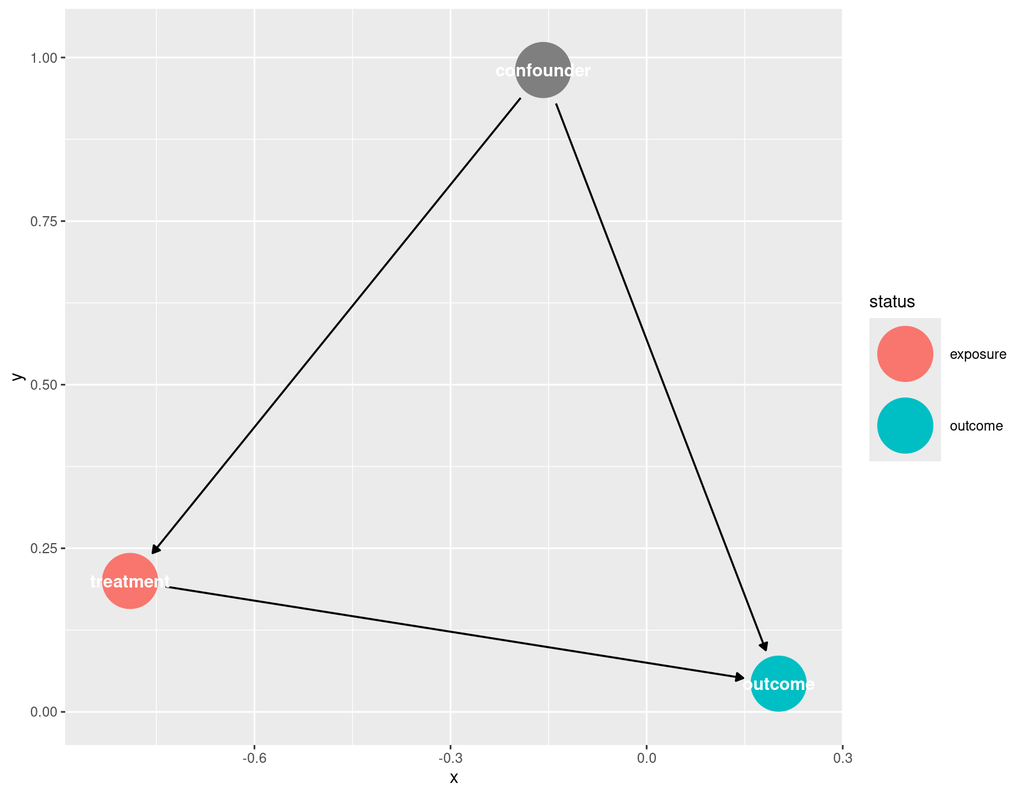

**The software can’t make causal decisions for you - but it can check your logic**

## Example 2: Antibiotic Treatment

**Question**: Does a new antibiotic reduce recovery time?

**Variables**: - New antibiotic (yes/no) - Recovery time - Infection severity - Intensive care admission

**Key facts**: - Severe infections → more likely to get new antibiotic - Severe infections → longer recovery - New antibiotic requires monitoring → intensive care - Severe infections also → intensive care

**Q: Should we adjust for intensive care?**

## Antibiotic DAG

```r
library(ggdag)

dag <- dagify(
  recovery ~ antibiotic +
             severity +
             icu,
  antibiotic ~ severity,
  icu ~ antibiotic + severity,

  exposure = "antibiotic",
  outcome = "recovery"
)

ggdag_status(dag) +
  theme_dag()
```

**Severity** = Confounder  
**ICU** = Collider

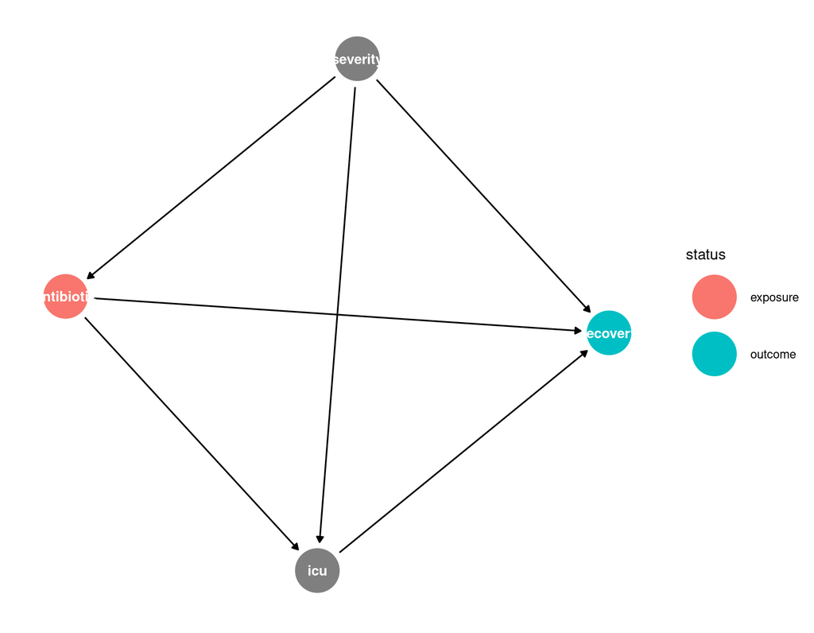

## What Should We Adjust For?

```r
ggdag_adjustment_set(dag)
```

**Result**: `{ infection_severity }`

**Correct model**:

```r
lm(recovery_time ~ antibiotic + infection_severity, data = hospital)
```

**Why?** - ✅ Adjusts for confounder (severity) - ❌ Does NOT adjust for collider (ICU)

**If we adjusted for ICU**: Would create spurious association between antibiotic and recovery through collider bias

## Example 3: Exercise & Heart Disease

**Question**: Does exercise reduce heart disease?

**Variables**: - Exercise (hours/week) - Heart disease (yes/no) - Age - Weight loss - Genetics

**Think about the causal structure before looking at the next slide…**

## Exercise DAG

```r
dag <- dagify(
  heart_disease ~ exercise +
                  age +
                  weight_loss +
                  genetics,
  exercise ~ age + genetics,
  weight_loss ~ exercise,

  exposure = "exercise",
  outcome = "heart_disease"
)

ggdag_adjustment_set(dag)
```

**Result**: `{ age, genetics }`

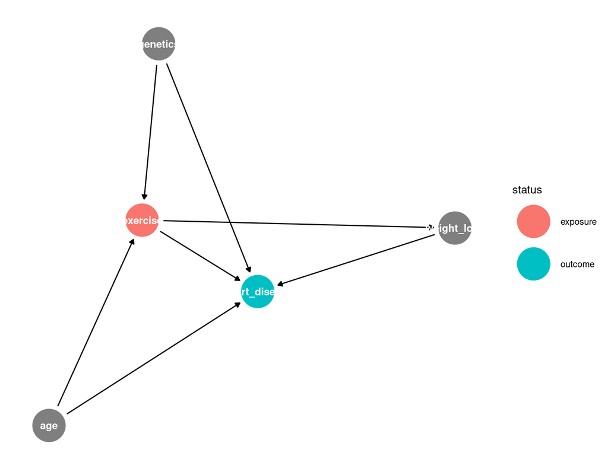

## Corrected model

**Correct model**:

```r
lm(heart_disease ~ exercise +
                   age +
                   genetics,
   data = health)
```

**Why?** - Age & genetics = confounders - Weight loss = mediator (don’t adjust for total effect)

## Example 4: Fertiliser & Crop Yield

**Question**: Does organic fertiliser increase yield?

**Variables**: - Fertiliser type - Crop yield - Soil quality - Rainfall - Pest damage

**Key fact**: Pest damage is caused by BOTH fertiliser type (attracts pests) AND rainfall (wet = more pests)

What is pest damage? **Collider!**

## Fertiliser DAG

```r
dag <- dagify(
  yield ~ fertiliser +
          soil +
          rainfall +
          pests,
  fertiliser ~ soil,
  pests ~ fertiliser +
          rainfall,

  exposure = "fertiliser",
  outcome = "yield"
)

ggdag_collider(dag)
```

**Pest damage is a collider**

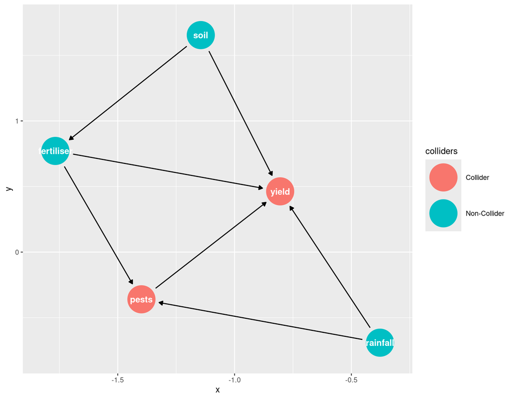

## Fertiliser DAG

**Correct model**:

```r
lm(yield ~ fertiliser +
           soil_quality +
           rainfall,
   data = farms)
```

**NOT pests** - that’s the collider!

## Common Pitfalls

**1. “Control for everything”** - ❌ Adjusts for mediators (wrong question) - ❌ Adjusts for colliders (creates bias) - ✅ Only adjust based on causal structure

**2. Confusing association with causation** - Just because X correlates with treatment and outcome doesn’t make it a confounder - Check: Does X *cause* both?

**3. Ignoring temporal order** - Causes must come before effects - Drought during fire year can’t cause thinning decisions made years earlier

**4. Adjusting for treatment consequences** - Variables caused by treatment are mediators or colliders - Usually shouldn’t adjust (unless you want direct effect)

## Decision Workflow

**Before running ANY regression**:

1. **Draw your DAG**
   - What is exposure/treatment?
   - What is outcome?
   - What causes what?
2. **Identify variable roles**
   - Confounders (adjust)
   - Mediators (depends on question)
   - Colliders (never adjust)
3. **Use ggdag to check**
   - `ggdag_adjustment_set()` - what to include
   - `ggdag_collider()` - what to avoid
4. **Fit appropriate model**
   - Include confounders
   - Exclude mediators (for total effect) or include (for direct effect)
   - Never include colliders
5. **Be transparent**
   - Report your DAG
   - Justify decisions
   - Acknowledge assumptions

## Practical Guidance

**When planning your analysis**:

✅ **Do**: - Draw DAGs before collecting data - Use subject knowledge to build causal models - Test specific, pre-planned hypotheses - Use hierarchical regression for exploration - Adjust for confounders - Be transparent about decisions

❌ **Don’t**: - Use stepwise/automated selection - Adjust for mediators (unless you want direct effect) - Adjust for colliders - Let software make causal decisions - Confuse statistical significance with causal validity - Model dredge

## Key Takeaways

**1. Statistical significance ≠ Causal validity** - p < 0.05 doesn’t mean you’ve found a cause

**2. Model specification is a scientific decision** - Based on causal theory, not statistical tests

**3. Three critical structures**: - Confounders: adjust for them - Mediators: depends on your question - Colliders: never adjust

**4. DAGs make assumptions explicit** - Force you to think causally - Help avoid common mistakes - Improve transparency

**5. There are no automatic solutions** - No algorithm can replace causal thinking - Domain knowledge is essential

## What’s Next?

**In the workshop you will**: - Build DAGs from biological scenarios - Use `ggdag` to analyse causal structures - See how wrong adjustments create bias - Practice with real datasets - Apply this to your own research questions

**Further reading**: - Coursebook chapter on Causal Inference with DAGs - Huntington-Klein (2021) [“The Effect”](https://theeffectbook.net/index.html)

## Questions?

**Think about**: - Your own research/projects - What variables might be confounders? - What might be mediators? - Are there potential colliders?

**Common questions**:

Q: “When is it OK to use AIC?”  
A: For comparing specific hypotheses, not for variable hunting

Q: “What if I’m not sure about the causal structure?”  
A: Draw multiple DAGs, check robustness. Honesty about uncertainty is better than false confidence

Q: “Can I ever adjust for a mediator?”  
A: Yes - if you specifically want the direct effect. Just be clear that’s what you’re estimating

## Summary

**The old way**: 1. Collect data 2. Put ALL predictors in 3. Report “significant” variables 4. Hope for the best

**The principled way**: 1. Draw causal DAG (before data!) 2. Identify confounders, mediators, colliders 3. Use ggdag to check logic 4. Fit causally-informed model 5. Interpret appropriately

> **Model selection is too important to be left to algorithms**

**See you in the workshop!**

## Backup Slides

### Detailed AIC Example (Backup 1)

```r
model1 <- lm(height ~ fertiliser, data = plants)
model2 <- lm(height ~ fertiliser + sunlight, data = plants)

AIC(model1, model2)
```

```
        df      AIC
model1   3   456.2
model2   4   423.8
```

**Interpretation**: - Model 2 has lower AIC (better fit despite extra parameter) - But this doesn’t tell you if sunlight is a confounder! - Need causal reasoning

## Using drop1() (Backup 2)

```r
full_model <- lm(height ~ fertiliser * sunlight, data = plants)

drop1(full_model, test = "F")
```

```
                      Df Sum of Sq    RSS    AIC F value   Pr(>F)
<none>                             156.2  78.1
fertiliser:sunlight    1     124.5  280.7  95.3  18.23  <0.001 ***
```

**Use for**: Testing if interaction can be removed  
**Don’t use for**: Choosing which main effects to include (use DAG instead)